# Exploratory Data Analysis - Trends in Opioid Prescriptions

Kyle Brewster

# Data Cleaning & Setup

```r
library(pacman)
p_load(dplyr, readr, skimr, ggplot2, tidyverse, tidymodels, janitor, magrittr)

opioid_list = read.csv("opioids.csv")
overdose_df = read.csv("overdoses.csv")
prescriber_df = read.csv("prescriber_info.csv")
```

## Overview

```r
#skim(prescriber_df)
```

## Cleaning up

### The `Credentials` column

```r
# To get an idea of some of the more-common types of credentials
top_counts(prescriber_df$Credentials, max_levels = 20)
```

```
## [1] "MD: 7034, M.D: 6772, DDS: 1145, D.O: 866, PA-: 845, emp: 763, D.D: 717, DO: 549, NP: 469, DMD: 449, PA: 437, O.D: 353, FNP: 262, ARN: 256, DPM: 247, M.D: 243, D.M: 234, OD: 175, P.A: 168, CRN: 150"
```

```r
# Cleaning up the acronyms for some of the most common types of credential
scribe_MD <- prescriber_df %>%
  group_by(Credentials) %>%
  filter(Credentials == "MD"|
         Credentials == "M.D."|
         Credentials == "M.D"|
         Credentials == "M.D.,"|
         Credentials == "M,D"|
         Credentials == "MD."|
         Credentials == "M.D,"|
         Credentials == "M.D")
scribe_DDS <- prescriber_df %>%
  filter(Credentials == "DDS"|
         Credentials == "DDS, MS,"|
         Credentials == "D.D.S."|
         Credentials == "DDS, MS"|
         Credentials == "DDS. MS"|
         Credentials == "MD, DDS"|
         Credentials == "DDS,MD"|
         Credentials == "DMD"|
         Credentials == "D.M.D."|
         Credentials == "D.M.D"|
         Credentials == "DDS, MD")
scribe_DO <- prescriber_df %>%
  group_by(Credentials) %>%
  filter(Credentials == "DO"|
         Credentials == "D.O."|
         Credentials == "D.O"|
         Credentials == "DO,"|
         Credentials == "D.O., M.D"|
         Credentials == "D.O., M.D."|
         Credentials == "D,O."|
         Credentials == "D.O.,")
scribe_PA <- prescriber_df %>%
  group_by(Credentials) %>%
  filter(Credentials == "PA"|
         Credentials == "P.A."|
         Credentials == "P.A.-C"|
         Credentials == "PA-C"|
         Credentials == "P.A"|
         Credentials == "PA-"|
         Credentials == "PA,"|
         Credentials == "PA."|
         Credentials == "P,A."|
         Credentials == "P.A.C"|
         Credentials == "P.A.,")
scribe_NP <- prescriber_df %>%
  group_by(Credentials) %>%
  filter(Credentials == "NP"|
         Credentials == "N.P."|
         Credentials == "N.P"|
         Credentials == "NP."|
         Credentials == "NP,"|
         Credentials == "N.P.,"|
         Credentials == "N P"|
         Credentials == "NURSE PRACTITIONER"|
         Credentials == "NP-C"|
         Credentials == "NP."|
         Credentials == "N P")
    ## Now to make the values more uniform
scribe_DDS = replace(scribe_DDS, 4,"DDS_DDM")
scribe_DO  = replace(scribe_DO, 4, "DO")
scribe_MD  = replace(scribe_MD, 4, "MD")
scribe_PA  = replace(scribe_PA, 4, "PA")
scribe_NP  = replace(scribe_NP, 4, "NP")
```

```r
scribe_joint = rbind(scribe_DDS, scribe_DO,
                     scribe_MD, scribe_NP,
                     scribe_PA)
```

### The `Specialty` column

Looking at the top specialties

```r
tab <- as.data.frame(table(prescriber_df$Specialty))
tab =arrange(tab, desc(Freq))
```

Filtering the data to only some the more-common values

```r
scribe_joint = scribe_joint %>%
  group_by(Specialty) %>%
  filter(Specialty == "Internal Medicine"|
         Specialty == "Family Practice"|
         Specialty == "Dentist"|
         Specialty == "Physician Assistant"|
         Specialty == "Nurse Practitioner"|
         Specialty == "Emergency Medicine"|
         Specialty == "Psychiatry"|
         Specialty == "Cardiology"|
         Specialty == "Obstetrics/Gynecology"|
         Specialty == "Orthopedic Surgery"|
         Specialty == "Optometry"|
         Specialty == "General Surgery")
```

### The State Naming Convention

Using the `state.abb` package to save some effort in narrowing this set down to 50 states and excluding territories, miscellaneous, or missing categories

```r
list_of_states = as.data.frame(cbind(state.abb))
list_of_states = list_of_states %>%
  mutate(State = state.abb) # Let's make the state variable have the same naming convention in both; and then filter out providers outside of our scope of interest
scribe_joint_nonstates = anti_join(scribe_joint, list_of_states, by = 'State')

# And now to get our sets for only the 50 states
scribe_joint = scribe_joint[
  !scribe_joint$State %in% scribe_joint_nonstates$State,
  ]
```

### Creating Variable for Total Number of Opioids Prescribed

Since we are working with multiple variables involving opioids, we therefore must avoid the mistake of including an opioid-variable in both the predictor and the outcome variables. Doing so would result in skewness of model accuracy since the predictors and the outcome are directly correlated and would predict an outcome that we already know.

Looking at the `opioid_list` data frame.

```r
unique(opioid_list$Generic.Name) # To see which medications are opioids
```

```
##  [1] "FENTANYL CITRATE"               "ACETAMINOPHEN WITH CODEINE"
##  [3] "CODEINE/BUTALBITAL/ASA/CAFFEIN" "DIHYDROCODEINE/ASPIRIN/CAFFEIN"
##  [5] "MORPHINE SULFATE"               "OPIUM/BELLADONNA ALKALOIDS"
##  [7] "BUPRENORPHINE HCL"              "BUTALBIT/ACETAMIN/CAFF/CODEINE"
##  [9] "BUTORPHANOL TARTRATE"           "BUPRENORPHINE"
## [11] "CODEINE/CARISOPRODOL/ASPIRIN"   "CODEINE SULFATE"
## [13] "HYDROCODONE/ACETAMINOPHEN"      "TRAMADOL HCL"
## [15] "MEPERIDINE HCL"                 "MEPERIDINE HCL/PF"
## [17] "HYDROMORPHONE HCL"              "HYDROMORPHONE HCL/PF"
## [19] "METHADONE HCL"                  "FENTANYL"
## [21] "MORPHINE SULFATE/PF"            "OXYCODONE HCL/ACETAMINOPHEN"
## [23] "OXYCODONE HCL/ASPIRIN"          "HYDROCODONE/IBUPROFEN"
## [25] "LEVORPHANOL TARTRATE"           "NALBUPHINE HCL"
## [27] "TAPENTADOL HCL"                 "OXYMORPHONE HCL"
## [29] "OPIUM TINCTURE"                 "OXYCODONE HCL"
## [31] "IBUPROFEN/OXYCODONE HCL"        "PENTAZOCINE HCL/ACETAMINOPHEN"
## [33] "PENTAZOCINE HCL/NALOXONE HCL"   "PENTAZOCINE LACTATE"
## [35] "TRAMADOL HCL/ACETAMINOPHEN"     "DHCODEINE BT/ACETAMINOPHN/CAFF"
## [37] "HYDROCODONE BITARTRATE"
```

```r
top_opioids = rbind(
  opioid_list[grep("BUPRENORPHINE", opioid_list$Generic.Name),],
  opioid_list[grep("BUTORPHANOL", opioid_list$Generic.Name),],
  opioid_list[grep("CODEINE", opioid_list$Generic.Name),],
  opioid_list[grep("FENTANYL", opioid_list$Generic.Name),],
  opioid_list[grep("HYDROCODONE", opioid_list$Generic.Name),],
  opioid_list[grep("HYDROMORPHONE", opioid_list$Generic.Name),],
  opioid_list[grep("LEVORPHANOL", opioid_list$Generic.Name),],
  opioid_list[grep("MEPERIDINE", opioid_list$Generic.Name),],
  opioid_list[grep("METHADONE", opioid_list$Generic.Name),],
  opioid_list[grep("MORPHINE", opioid_list$Generic.Name),],
  opioid_list[grep("NALBUPHINE", opioid_list$Generic.Name),],
  opioid_list[grep("OPIUM", opioid_list$Generic.Name),],
  opioid_list[grep("OXYCODONE", opioid_list$Generic.Name),],
  opioid_list[grep("OXYMORPHONE", opioid_list$Generic.Name),],
  opioid_list[grep("PENTAZOCINE", opioid_list$Generic.Name),],
  opioid_list[grep("TRAMADOL", opioid_list$Generic.Name),])
```

```r
working_df = scribe_joint %>%
  select(contains(c("NPI","Gender","State","Credentials","Specialty",
                  "HYDROCODONE","OXYCONTIN",
                  "CODEINE","FENTANYL","PENTAZOCINE",
                  "DIHYDROCODEINE","Opioid.Prescriber",
                  "OPIUM","BUPRENORPHINE","BUTALBIT","BUTORPHANOL",
                  "TRAMADOL","MEPERIDINE","HYDROMORPHONE","METHADONE",
                  "MORPHINE","OXYCODONE","LEVORPHANOL","NALBUPHINE",
                  "TAPENTADOL","OXYMORPHONE","OPIUM")))

# Now we can calculate the sum of opioid prescription written by each provider for the year
working_df$summ_var = rowSums(working_df[ ,c(6:18)])

# adding that column to our original data frame
scribe_joint$summ_var <- working_df$summ_var
```

### Removing Outliers

Looking at the `summ_var` variable that we created, we can see that there is one provider in particular that prescribed a significantly higher amount than any other providers. Let’s remove that observation from our data.

```r
scribe_joint = subset(scribe_joint, summ_var<4000)
```

### Creating Factor Variables

```r
scribe_joint = scribe_joint %>%
  mutate(Gender = as.factor(Gender),
         State  = as.factor(State),
         Credentials = as.factor(Credentials),
         Specialty   = as.factor(Specialty))
```

### Adjustments for Population

```r
# Creating a variable for per capita rates
overdose_df$Deaths <- as.numeric(gsub(",","",overdose_df$Deaths))
overdose_df$Population <- as.numeric(
  gsub(",","",overdose_df$Population))
    # Removing commas first to avoid errors in math
overdose_df$deaths_per_capita = (
  overdose_df$Deaths/overdose_df$Population
  )*100000 # per 100 thousand

df = scribe_joint %>%
  group_by(State) %>%
  summarise(state_opioid_volume = sum(summ_var)) %>%
  arrange(State)
overdose_df$state_opioid_volume <- df$state_opioid_volume
    # To give us total opioid prescriptions in each state

# which will allow us to determine the rate-per-thousand people
overdose_df %<>% mutate(opioids_per_cap =
                          (state_opioid_volume/Population)*1000)
```

## Data Visualization

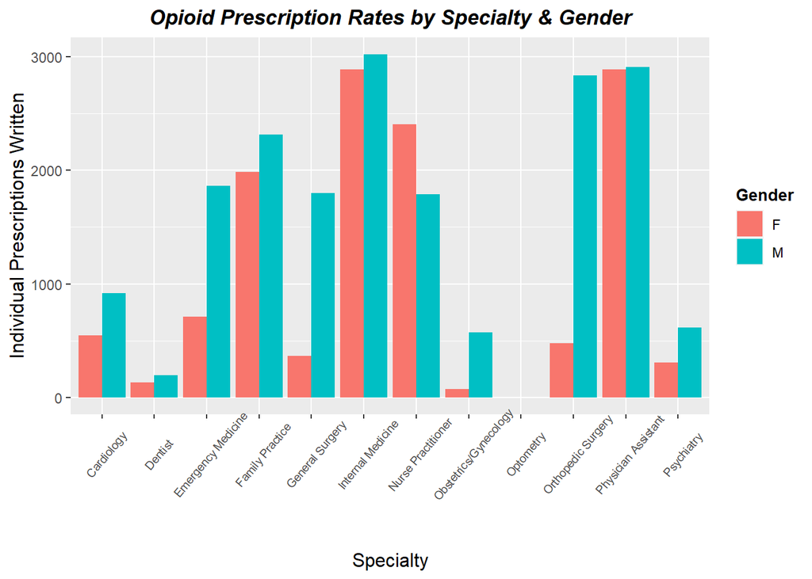

```r
# Differences when grouped by specialty
ggp1 = ggplot(
  scribe_joint,aes(x = Specialty, y = summ_var, fill = Gender)) +
  geom_bar(stat = "identity", position = "dodge") +
  labs(x = "Specialty",
       y = "Individual Prescriptions Written",
       fill = "Gender",
       title = "Opioid Prescription Rates by Specialty & Gender") +
  theme(plot.title = element_text(hjust = 0.5, face="bold.italic"),
        axis.title.x = element_text(size = 12),
        axis.text.x = element_text(size = 7, angle=50,margin = margin(t = 20)),
        axis.title.y = element_text(size = 12),
        legend.title = element_text(face="bold", size = 10))
# Differences when grouped by credentials
ggp2 = ggplot(
  scribe_joint,aes(x = Credentials, y = summ_var, fill = Gender)) +
  geom_bar(stat = "identity", position = "dodge") +
  labs(x = "Credential",
       y = "Individual Prescriptions Written",
       fill = "Gender",
       title = "Opioid Prescription Rates by Credentials & Gender") +
  theme(plot.title = element_text(hjust = 0.5, face="bold.italic"),
        axis.title.x = element_text(size = 12),
        axis.text.x = element_text(size = 7),
        axis.title.y = element_text(size = 12),
        legend.title = element_text(face="bold", size = 10))
ggp1
```

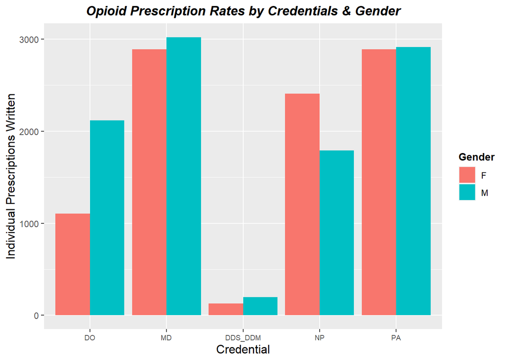

```r
ggp2
```

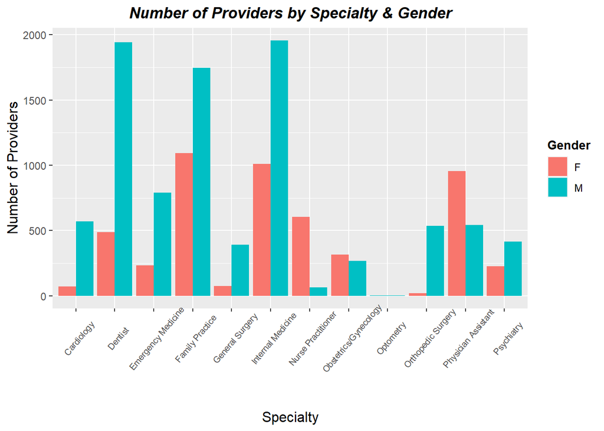

```r
ggp3 = scribe_joint %>%
  group_by(Gender) %>%
  summarise(plyr::count(Specialty))%>%
  ggplot(.,aes(x = x, y = freq, fill = Gender)) +
  geom_bar(stat = "identity", position = "dodge")+
  labs(x = "Specialty",
       y = "Number of Providers",
       fill = "Gender",
       title = "Number of Providers by Specialty & Gender") +
  theme(plot.title = element_text(hjust = 0.5, face="bold.italic"),
        axis.title.x = element_text(size = 12),
        axis.text.x = element_text(size = 7, angle=50,margin = margin(t = 20)),
        axis.title.y = element_text(size = 12),
        legend.title = element_text(face="bold", size = 10))
ggp4 = scribe_joint %>%
  group_by(Gender) %>%
  summarise(plyr::count(Credentials))%>%
  ggplot(.,aes(x = x, y = freq, fill = Gender)) +
  geom_bar(stat = "identity", position = "dodge")+
  labs(x = "Credential",
       y = "Number of Providers",
       fill = "Gender",
       title = "Number of Providers by Credentials & Gender") +
  theme(plot.title = element_text(hjust = 0.5, face="bold.italic"),
        axis.title.x = element_text(size = 12),
        axis.text.x = element_text(size = 7),
        axis.title.y = element_text(size = 12),
        legend.title = element_text(face="bold", size = 10))
ggp3
```

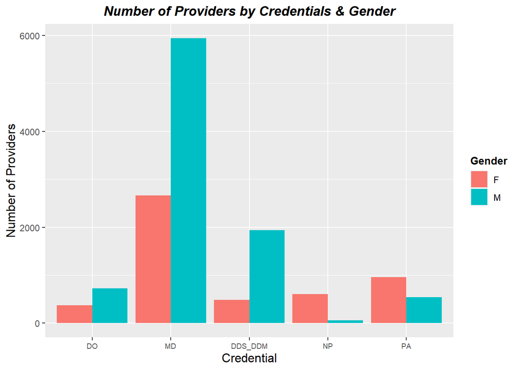

```r
ggp4
```

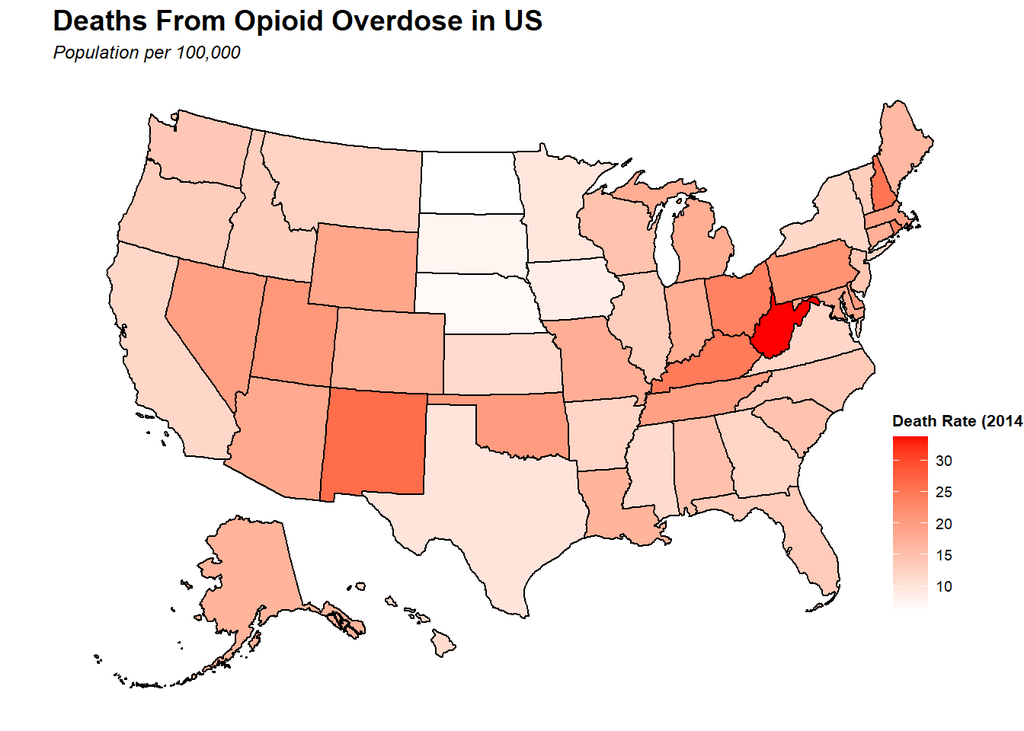

```r
library(usmap)
library(ggpattern)
statepop <- statepop %>% filter(abbr!='DC')
statepop$per_cap_death <- overdose_df$deaths_per_capita

map_of_deaths <- plot_usmap(data = statepop, values = "per_cap_death", color = "black")+
  labs(title = "Deaths From Opioid Overdose in US",
               subtitle = "Population per 100,000")+
  theme(plot.title = element_text(face="bold", size = 14),
        plot.subtitle = element_text(face = "italic"),
        legend.title = element_text(face = "bold", size = 8),
        legend.position = c(0.9, 0.15))+
  scale_fill_continuous(
    low = "white", high = "red", name = "Death Rate (2014)")
map_of_deaths
```

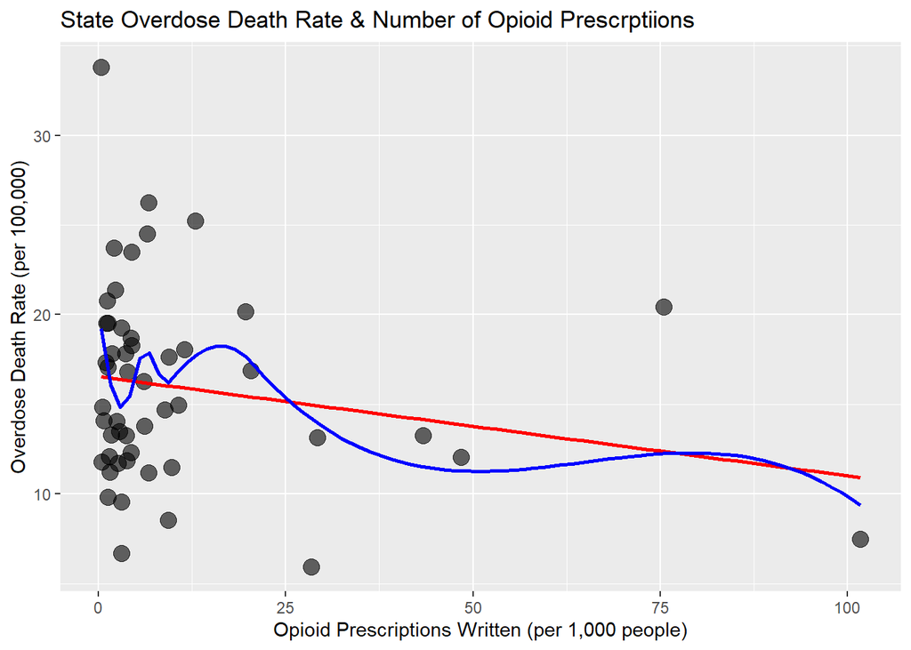

```r
plot_overdose_script = ggplot(
  overdose_df, aes(x=opioids_per_cap, y=deaths_per_capita)) +
  geom_point(size=4, alpha=.6, color="black")+
  geom_smooth(method = 'lm', se=F, color="red")+
  geom_smooth(method = "loess", se=F, color="blue")+
  xlim(0,102)+
  ylab("Overdose Death Rate (per 100,000)")+
  xlab("Opioid Prescriptions Written (per 1,000 people)")+
  labs(title =
         "State Overdose Death Rate & Number of Opioid Prescrptiions")
plot_overdose_script
```

# Training & Testing

```r
set.seed(1234) # Setting seed for reproducibility
train_df = scribe_joint %>%
  sample_frac(0.8) # Partitioning 20% to be used for testing
test_df  = anti_join(
  scribe_joint, train_df, by = 'NPI')

# Now lets remove the `NPI` variable to make work easier henceforth
train_df = train_df %>% select(-c("NPI"))
test_df = test_df %>% select(-c("NPI"))
```

## *Model 1*: Multivariate Regression

```r
# Let's make a copy of the train/test set that we can play with for this model
m1_train <- train_df
m1_test  <- test_df
```

If we want to answer this question, we should remove the variables of the individual opioids and only include the `summ_var` variable we created for total opioids prescribed. Removing the additional variables would prevent double-counting in the data.

```r
# Using variable from working_df from before to get list of variables to remove from m1_train
colnames(working_df)
```

```
##  [1] "NPI"                       "Gender"
##  [3] "State"                     "Credentials"
##  [5] "Specialty"                 "HYDROCODONE.ACETAMINOPHEN"
##  [7] "OXYCONTIN"                 "ACETAMINOPHEN.CODEINE"
##  [9] "FENTANYL"                  "Opioid.Prescriber"
## [11] "IPRATROPIUM.BROMIDE"       "TRAMADOL.HCL"
## [13] "HYDROMORPHONE.HCL"         "METHADONE.HCL"
## [15] "MORPHINE.SULFATE"          "MORPHINE.SULFATE.ER"
## [17] "OXYCODONE.ACETAMINOPHEN"   "OXYCODONE.HCL"
## [19] "summ_var"
```

```r
m1_train = m1_train %>%
  select(-c("HYDROCODONE.ACETAMINOPHEN",
            "OXYCONTIN","ACETAMINOPHEN.CODEINE",
            "FENTANYL","Opioid.Prescriber",
            "TRAMADOL.HCL","HYDROMORPHONE.HCL",
            "METHADONE.HCL","MORPHINE.SULFATE",
            "MORPHINE.SULFATE.ER",
            "OXYCODONE.ACETAMINOPHEN",
            "OXYCODONE.HCL"))
```

```r
p_load(tidyverse, caret, leaps)

set.seed(123)
# Forward step wise selection
fwd_step = train(
  summ_var ~.,
  data = m1_train,
  trControl = trainControl(method = "cv", number = 5),
  method = "leapForward",
  tuneGrid = expand.grid(nvmax = 1:15)
)
fwd_step$results
```

```
##    nvmax     RMSE  Rsquared      MAE   RMSESD RsquaredSD    MAESD
## 1      1 142.9462 0.5889351 67.95358 9.012730 0.02018443 1.853411
## 2      2 128.1006 0.6694549 62.71504 4.961419 0.01403452 1.281382
## 3      3 120.2452 0.7102281 59.75820 5.833873 0.01121955 1.506387
## 4      4 115.5554 0.7320890 57.86897 4.411791 0.01680322 1.402685
## 5      5 113.0243 0.7437949 55.51938 4.602188 0.01436761 1.105121
## 6      6 111.1988 0.7516913 53.73136 3.880417 0.01627388 1.393002
## 7      7 108.0603 0.7648023 52.33373 3.102894 0.01421277 0.809943
## 8      8 107.1782 0.7686659 51.76848 3.298020 0.01190997 1.205059
## 9      9 106.0462 0.7735734 51.37989 3.802985 0.01091996 1.261378
## 10    10 104.9922 0.7784379 51.00413 3.694032 0.01140687 1.131310
## 11    11 105.3073 0.7775196 50.87328 4.063669 0.01591674 1.419487
## 12    12 104.6231 0.7803991 49.95771 4.434914 0.01709791 1.191680
## 13    13 106.2271 0.7742025 49.73829 3.873788 0.01478199 1.207771
## 14    14 106.0036 0.7751666 49.52943 4.773148 0.01895048 1.298049
## 15    15 105.7240 0.7764202 49.50593 4.313467 0.01663582 1.149661
```

```r
fwd_step$bestTune
```

```
##    nvmax
## 12    12
```

```r
# Backward step wise selection
back_step = train(
  summ_var ~.,
  data = m1_train,
  trControl = trainControl(method = "cv", number = 5),
  method = "leapBackward",
  tuneGrid = expand.grid(nvmax = 1:15)
)
back_step$results
```

```
##    nvmax     RMSE  Rsquared      MAE    RMSESD  RsquaredSD    MAESD
## 1      1 147.5288 0.5616769 71.38966 13.139949 0.042923270 8.705169
## 2      2 131.1565 0.6529783 63.98359  8.908965 0.019530571 4.074801
## 3      3 122.5604 0.6973548 60.70188  9.706783 0.025613525 3.701787
## 4      4 116.6978 0.7260008 58.50078  7.923951 0.013846784 3.196471
## 5      5 115.5123 0.7317133 57.38717  7.242762 0.011822267 2.972636
## 6      6 112.4236 0.7456669 55.99648  6.190942 0.009952097 3.008983
## 7      7 110.3052 0.7549938 54.12002  5.867603 0.011367704 2.565357
## 8      8 108.2452 0.7638922 52.85418  5.909550 0.011694650 2.515367
## 9      9 105.9964 0.7736059 52.04085  5.262633 0.010746906 2.488759
## 10    10 106.6327 0.7712167 51.33036  8.351863 0.021385624 2.788668
## 11    11 105.8898 0.7742964 51.09143  6.888476 0.017936588 2.433166
## 12    12 105.6434 0.7750603 50.81237  6.862724 0.021387713 2.200488
## 13    13 105.0630 0.7772380 50.40047  5.924330 0.022142826 1.958428
## 14    14 106.1059 0.7731446 50.34965  7.771442 0.028811771 1.938923
## 15    15 106.4856 0.7717127 50.37024  8.212358 0.029832796 1.689108
```

```r
back_step$r
```

```r
fin_fwd_step_list = as.data.frame(coef(fwd_step$finalModel,12))
fin_bck_step_list = as.data.frame(coef(back_step$finalModel,13))
print(fin_bck_step_list)
```

```
##                             coef(back_step$finalModel, 13)
## (Intercept)                                     13.3716205
## SpecialtyOrthopedic Surgery                    119.6345098
## BACLOFEN                                         0.9503030
## CARISOPRODOL                                     3.8013034
## CYCLOBENZAPRINE.HCL                              2.9703701
## DIVALPROEX.SODIUM.ER                            -1.7089292
## GABAPENTIN                                       0.4771488
## LORAZEPAM                                        0.9163253
## LYRICA                                           1.8918060
## METHOCARBAMOL                                    2.6123489
## ONDANSETRON.HCL                                  2.5591120
## PREDNISONE                                       0.6453914
## PROAIR.HFA                                       0.5089056
## TIZANIDINE.HCL                                   1.6215341
```

```r
print(fin_fwd_step_list)
```

```
##                             coef(fwd_step$finalModel, 12)
## (Intercept)                                    12.8747926
## SpecialtyOrthopedic Surgery                   119.0406428
## CARISOPRODOL                                    4.0987142
## CYCLOBENZAPRINE.HCL                             3.2235913
## DIVALPROEX.SODIUM.ER                           -1.5447693
## GABAPENTIN                                      0.5583611
## LEVOTHYROXINE.SODIUM                            0.1294654
## LORAZEPAM                                       0.7885353
## LYRICA                                          1.8600224
## METHOCARBAMOL                                   2.6424817
## ONDANSETRON.HCL                                 2.3856531
## PREDNISONE                                      0.6304748
## TIZANIDINE.HCL                                  1.6664675
```

```r
m1_train = m1_train %>%
  mutate(orth_surg_dummy = as.factor(
    if_else(Specialty == "Orthopedic Surgery",1,0))
  )

mod1 = lm(data = m1_train, method = "lm", summ_var~
           orth_surg_dummy + CARISOPRODOL +
           CYCLOBENZAPRINE.HCL+METHOCARBAMOL+
           ONDANSETRON.HCL+LYRICA+TIZANIDINE.HCL+
            LORAZEPAM+PREDNISONE+GABAPENTIN)
summary(mod1)
```

```
##
## Call:
## lm(formula = summ_var ~ orth_surg_dummy + CARISOPRODOL + CYCLOBENZAPRINE.HCL +
##     METHOCARBAMOL + ONDANSETRON.HCL + LYRICA + TIZANIDINE.HCL +
##     LORAZEPAM + PREDNISONE + GABAPENTIN, data = m1_train, method = "lm")
##
## Residuals:
##      Min       1Q   Median       3Q      Max
## -1235.33   -16.99   -13.54    12.46  1688.54
##
## Coefficients:
##                      Estimate Std. Error t value Pr(>|t|)
## (Intercept)          13.53637    1.09557   12.36   <2e-16 ***
## orth_surg_dummy1    116.78447    5.03220   23.21   <2e-16 ***
## CARISOPRODOL          4.09686    0.10102   40.56   <2e-16 ***
## CYCLOBENZAPRINE.HCL   3.41291    0.10672   31.98   <2e-16 ***
## METHOCARBAMOL         2.71512    0.19653   13.81   <2e-16 ***
## ONDANSETRON.HCL       2.67239    0.15231   17.55   <2e-16 ***
## LYRICA                2.10255    0.07984   26.34   <2e-16 ***
## TIZANIDINE.HCL        1.56360    0.07336   21.32   <2e-16 ***
## LORAZEPAM             0.57493    0.02746   20.93   <2e-16 ***
## PREDNISONE            0.87213    0.04227   20.63   <2e-16 ***
## GABAPENTIN            0.65028    0.02476   26.26   <2e-16 ***
## ---
## Signif. codes:  0 '***' 0.001 '**' 0.01 '*' 0.05 '.' 0.1 ' ' 1
##
## Residual standard error: 103.7 on 11436 degrees of freedom
## Multiple R-squared:  0.7835, Adjusted R-squared:  0.7833
## F-statistic:  4138 on 10 and 11436 DF,  p-value: < 2.2e-16
```

Looking at some measurements of model accuracy

```r
m1_train$resid <- resid(mod1)
m1_train$fitted <- fitted(mod1)

sqrt(mean((m1_train$summ_var - m1_train$fitted)^2)) # to calculate MSE
```

```
## [1] 103.6392
```

Not the best-performing model, but let’s see nonetheless how it performs when facing the testing set. Perhaps the insight to learn is that we cannot successfully predict opioid prescription rates from these lists of other prescribed medications

## *Model 2*: Decision Trees

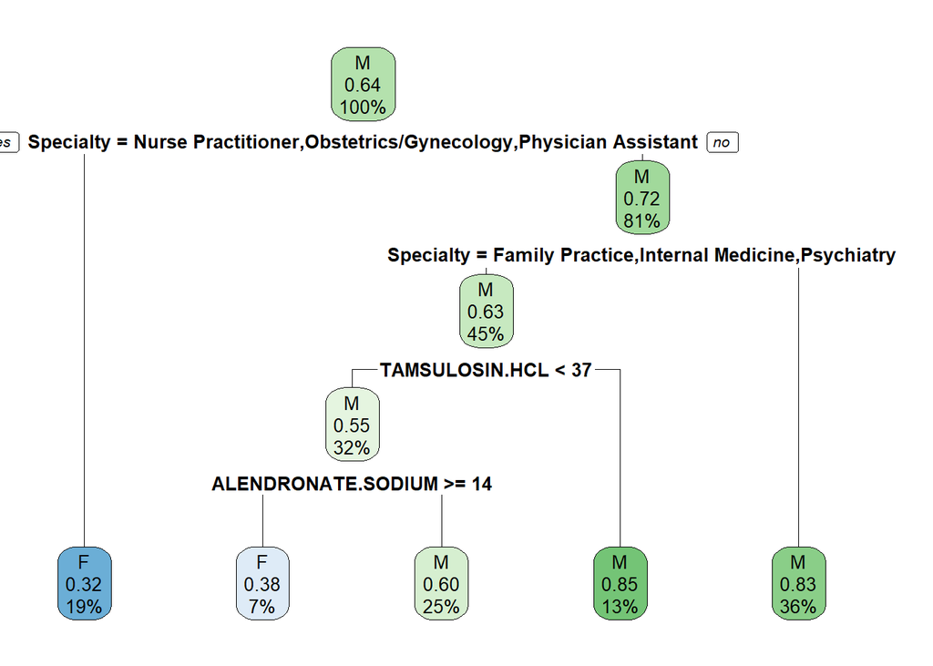

```r
library(rpart.plot)
m2_train <- train_df %>% na.omit(.)
set.seed(1234)
default_cv = m2_train %>% vfold_cv(v =5)
# Define the decision tree
default_tree = decision_tree(mode ="classification",
                             cost_complexity = tune(),
                             tree_depth = tune()) %>%
  set_engine("rpart")
# Defining recipe
default_recipe = recipe(Gender ~., data = m2_train)
# Defining workflow
default_flow = workflow() %>%
  add_model(default_tree) %>%
  add_recipe(default_recipe)
# Tuning
default_cv_fit = default_flow %>%
  tune_grid(
    default_cv,
    grid = expand_grid(
      cost_complexity = seq(0, 0.15, by = 0.01),
      tree_depth = c(1,2,5,10),
    ),
    metrics = metric_set(accuracy, roc_auc)
  )
# Fitting the best model
best_flow = default_flow %>%
  finalize_workflow(select_best(default_cv_fit, metric = "accuracy")) %>%
  fit(data = m2_train)
# Choosing the best model
best_tree = best_flow %>% extract_fit_parsnip()
# Plotting the tree
best_tree$fit %>% rpart.plot(roundint = FALSE)
```

## *Model 3*: Binscatter Random Forest

```r
m3_train <- train_df
m3_test <- test_df
# Adding indicator vriable for Surgons
m3_train %<>%
  mutate(orth_surg_dummy = as.factor(
    if_else(Specialty == "Orthopedic Surgery",1,0)))
m3_test %<>%
  mutate(orth_surg_dummy = as.factor(
    if_else(Specialty == "Orthopedic Surgery",1,0)))

# Splitting data into bins
m3_train %<>% mutate(new_bin = ntile(summ_var, n=30)) %>%
   mutate(new_bin = as.factor(new_bin))
str(m3_train$new_bin)
```

```
##  Factor w/ 30 levels "1","2","3","4",..: 1 1 1 24 1 1 26 1 1 1 ...
```

```r
m3_train = m3_train %>%
   group_by(new_bin) %>%
   mutate(avg_sum_var = mean(summ_var))
```

## *Model 4*: Support Vector Machine (SVM)

For this model, let’s see if we can accurately predict the gender of a provider.

```r
m4_train <- train_df
m4_test <- test_df

pacman::p_load(e1071)
```

Now to prepare the data for making our predictions of interest

```r
# Defining our variables of prediction and outcome
x = m4_train[,-1]
y = m4_train[1]
```

Now running the model (takes a while, be patient)

```r
svm_model = svm(Gender ~ .,
                 data = m4_train)
summary(svm_model)
```

```
##
## Call:
## svm(formula = Gender ~ ., data = m4_train)
##
##
## Parameters:
##    SVM-Type:  C-classification
##  SVM-Kernel:  radial
##        cost:  1
##
## Number of Support Vectors:  7820
##
##  ( 4270 3550 )
##
##
## Number of Classes:  2
##
## Levels:
##  F M
```

```r
preds = predict(svm_model,x)
# Ensure caret package is loaded for line below
confusionMatrix(preds, y$Gender)
```

```
## Confusion Matrix and Statistics
##
##           Reference
## Prediction    F    M
##          F 2011  554
##          M 2059 6823
##
##                Accuracy : 0.7717
##                  95% CI : (0.7639, 0.7794)
##     No Information Rate : 0.6444
##     P-Value [Acc > NIR] : < 2.2e-16
##
##                   Kappa : 0.4569
##
##  Mcnemar's Test P-Value : < 2.2e-16
##
##             Sensitivity : 0.4941
##             Specificity : 0.9249
##          Pos Pred Value : 0.7840
##          Neg Pred Value : 0.7682
##              Prevalence : 0.3556
##          Detection Rate : 0.1757
##    Detection Prevalence : 0.2241
##       Balanced Accuracy : 0.7095
##
##        'Positive' Class : F
##
```

```r
summary(svm_model)
```

```
##
## Call:
## svm(formula = Gender ~ ., data = m4_train)
##
##
## Parameters:
##    SVM-Type:  C-classification
##  SVM-Kernel:  radial
##        cost:  1
##
## Number of Support Vectors:  7820
##
##  ( 4270 3550 )
##
##
## Number of Classes:  2
##
## Levels:
##  F M
```

# Testing

## *Model 1*: Multivariate Regression

```r
m1_test = m1_test %>%
  mutate(orth_surg_dummy = as.factor(
    if_else(Specialty == "Orthopedic Surgery",1,0))
  )
# Using the variables selected with stepwise algorithm
mod1t = lm(data = m1_test, summ_var~
           orth_surg_dummy + CARISOPRODOL +
           CYCLOBENZAPRINE.HCL+METHOCARBAMOL+
           ONDANSETRON.HCL+LYRICA+TIZANIDINE.HCL+
            LORAZEPAM+PREDNISONE+GABAPENTIN)
summary(mod1t)
```

```
##
## Call:
## lm(formula = summ_var ~ orth_surg_dummy + CARISOPRODOL + CYCLOBENZAPRINE.HCL +
##     METHOCARBAMOL + ONDANSETRON.HCL + LYRICA + TIZANIDINE.HCL +
##     LORAZEPAM + PREDNISONE + GABAPENTIN, data = m1_test)
##
## Residuals:
##     Min      1Q  Median      3Q     Max
## -1267.8   -14.2   -14.2    12.9  1168.4
##
## Coefficients:
##                     Estimate Std. Error t value Pr(>|t|)
## (Intercept)         14.19839    2.31422   6.135 9.68e-10 ***
## orth_surg_dummy1    77.78581   10.64788   7.305 3.57e-13 ***
## CARISOPRODOL         6.09944    0.23139  26.360  < 2e-16 ***
## CYCLOBENZAPRINE.HCL  3.88640    0.20764  18.717  < 2e-16 ***
## METHOCARBAMOL        1.85239    0.38520   4.809 1.60e-06 ***
## ONDANSETRON.HCL      2.00514    0.33900   5.915 3.72e-09 ***
## LYRICA               1.83852    0.20389   9.017  < 2e-16 ***
## TIZANIDINE.HCL       0.95089    0.16993   5.596 2.40e-08 ***
## LORAZEPAM            0.67389    0.05293  12.733  < 2e-16 ***
## PREDNISONE           0.41070    0.08398   4.890 1.06e-06 ***
## GABAPENTIN           0.83131    0.05162  16.103  < 2e-16 ***
## ---
## Signif. codes:  0 '***' 0.001 '**' 0.01 '*' 0.05 '.' 0.1 ' ' 1
##
## Residual standard error: 109.6 on 2852 degrees of freedom
## Multiple R-squared:  0.7672, Adjusted R-squared:  0.7663
## F-statistic: 939.7 on 10 and 2852 DF,  p-value: < 2.2e-16
```

```r
m1_test$resid <- resid(mod1t)
m1_test$fitted <- fitted(mod1t)
sqrt(mean((m1_test$summ_var - m1_test$fitted)^2)) # to calculate MSE
```

```
## [1] 109.4119
```

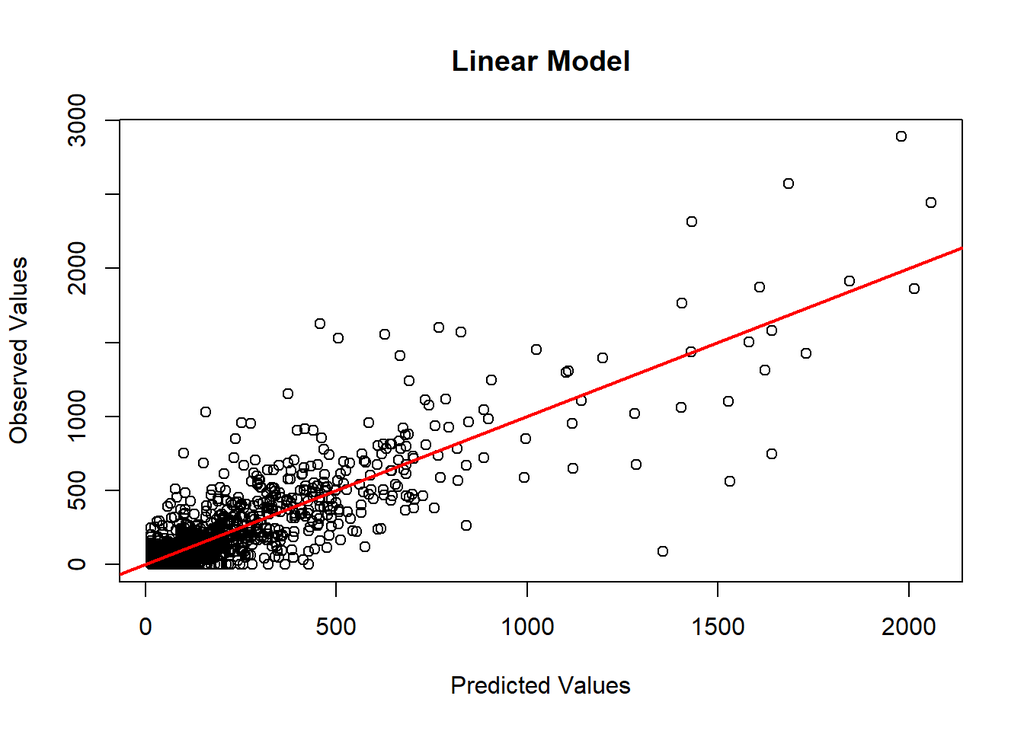

```r
plot(x=m1_test$fitted,
     m1_test$summ_var,
     xlab = "Predicted Values",
     ylab = "Observed Values",
     main = "Linear Model")
abline(a = 0,
       b = 1,
       col = "red",
       lwd = 2)
```